# Risk Factor Analysis

## Outcome Variable

**Outcome Variable:** sstunted

## Predictor Variables

**Intervention Variable:** meducyrs

**Adjustment Set:**

unadjusted

## Stratifying Variables

The analysis was stratified on these variable(s):

- agecat
- studyid
- country

## Data Summary

| agecat | studyid | country | A | n | nA | nAY0 | nAY1 |
| --- | --- | --- | --- | --- | --- | --- | --- |
| Birth | ki0047075b-MAL-ED | BANGLADESH | Q4 | 207 | 59 | 58 | 1 |
| Birth | ki0047075b-MAL-ED | BANGLADESH | Q1 | 207 | 40 | 37 | 3 |
| Birth | ki0047075b-MAL-ED | BANGLADESH | Q2 | 207 | 28 | 28 | 0 |
| Birth | ki0047075b-MAL-ED | BANGLADESH | Q3 | 207 | 80 | 77 | 3 |
| Birth | ki0047075b-MAL-ED | BRAZIL | Q4 | 190 | 65 | 62 | 3 |
| Birth | ki0047075b-MAL-ED | BRAZIL | Q1 | 190 | 40 | 39 | 1 |
| Birth | ki0047075b-MAL-ED | BRAZIL | Q2 | 190 | 36 | 34 | 2 |
| Birth | ki0047075b-MAL-ED | BRAZIL | Q3 | 190 | 49 | 47 | 2 |
| Birth | ki0047075b-MAL-ED | INDIA | Q4 | 183 | 51 | 49 | 2 |
| Birth | ki0047075b-MAL-ED | INDIA | Q1 | 183 | 27 | 26 | 1 |
| Birth | ki0047075b-MAL-ED | INDIA | Q2 | 183 | 43 | 42 | 1 |
| Birth | ki0047075b-MAL-ED | INDIA | Q3 | 183 | 62 | 61 | 1 |
| Birth | ki0047075b-MAL-ED | NEPAL | Q4 | 160 | 13 | 13 | 0 |
| Birth | ki0047075b-MAL-ED | NEPAL | Q1 | 160 | 21 | 20 | 1 |
| Birth | ki0047075b-MAL-ED | NEPAL | Q2 | 160 | 47 | 45 | 2 |
| Birth | ki0047075b-MAL-ED | NEPAL | Q3 | 160 | 79 | 76 | 3 |
| Birth | ki0047075b-MAL-ED | PERU | Q4 | 286 | 87 | 83 | 4 |
| Birth | ki0047075b-MAL-ED | PERU | Q1 | 286 | 60 | 60 | 0 |
| Birth | ki0047075b-MAL-ED | PERU | Q2 | 286 | 67 | 65 | 2 |
| Birth | ki0047075b-MAL-ED | PERU | Q3 | 286 | 72 | 70 | 2 |
| Birth | ki0047075b-MAL-ED | SOUTH AFRICA | Q4 | 262 | 72 | 72 | 0 |
| Birth | ki0047075b-MAL-ED | SOUTH AFRICA | Q1 | 262 | 51 | 51 | 0 |
| Birth | ki0047075b-MAL-ED | SOUTH AFRICA | Q2 | 262 | 82 | 80 | 2 |
| Birth | ki0047075b-MAL-ED | SOUTH AFRICA | Q3 | 262 | 57 | 57 | 0 |
| Birth | ki0047075b-MAL-ED | TANZANIA, UNITED REPUBLIC OF | Q4 | 107 | 2 | 2 | 0 |
| Birth | ki0047075b-MAL-ED | TANZANIA, UNITED REPUBLIC OF | Q1 | 107 | 15 | 15 | 0 |
| Birth | ki0047075b-MAL-ED | TANZANIA, UNITED REPUBLIC OF | Q2 | 107 | 20 | 19 | 1 |
| Birth | ki0047075b-MAL-ED | TANZANIA, UNITED REPUBLIC OF | Q3 | 107 | 70 | 67 | 3 |
| Birth | ki1000108-CMC-V-BCS-2002 | INDIA | Q4 | 90 | 7 | 7 | 0 |
| Birth | ki1000108-CMC-V-BCS-2002 | INDIA | Q1 | 90 | 15 | 15 | 0 |

[output cut: 538 more lines]

The following strata were considered:

- agecat: 12 months, studyid: ki0047075b-MAL-ED, country: BANGLADESH
- agecat: 12 months, studyid: ki0047075b-MAL-ED, country: BRAZIL
- agecat: 12 months, studyid: ki0047075b-MAL-ED, country: INDIA
- agecat: 12 months, studyid: ki0047075b-MAL-ED, country: NEPAL
- agecat: 12 months, studyid: ki0047075b-MAL-ED, country: PERU
- agecat: 12 months, studyid: ki0047075b-MAL-ED, country: SOUTH AFRICA
- agecat: 12 months, studyid: ki0047075b-MAL-ED, country: TANZANIA, UNITED REPUBLIC OF
- agecat: 12 months, studyid: ki1000108-CMC-V-BCS-2002, country: INDIA
- agecat: 12 months, studyid: ki1000108-IRC, country: INDIA
- agecat: 12 months, studyid: ki1000109-EE, country: PAKISTAN
- agecat: 12 months, studyid: ki1000304b-SAS-FoodSuppl, country: INDIA
- agecat: 12 months, studyid: ki1017093-NIH-Birth, country: BANGLADESH
- agecat: 12 months, studyid: ki1017093b-PROVIDE, country: BANGLADESH
- agecat: 12 months, studyid: ki1017093c-NIH-Crypto, country: BANGLADESH
- agecat: 12 months, studyid: ki1066203-TanzaniaChild2, country: TANZANIA, UNITED REPUBLIC OF
- agecat: 12 months, studyid: ki1112895-Guatemala BSC, country: GUATEMALA
- agecat: 12 months, studyid: ki1113344-GMS-Nepal, country: NEPAL
- agecat: 12 months, studyid: ki1126311-ZVITAMBO, country: ZIMBABWE
- agecat: 12 months, studyid: ki1135781-COHORTS, country: GUATEMALA
- agecat: 12 months, studyid: ki1135781-COHORTS, country: INDIA
- agecat: 12 months, studyid: ki1135781-COHORTS, country: PHILIPPINES
- agecat: 12 months, studyid: ki1148112-LCNI-5, country: MALAWI
- agecat: 18 months, studyid: ki0047075b-MAL-ED, country: BANGLADESH
- agecat: 18 months, studyid: ki0047075b-MAL-ED, country: BRAZIL
- agecat: 18 months, studyid: ki0047075b-MAL-ED, country: INDIA
- agecat: 18 months, studyid: ki0047075b-MAL-ED, country: NEPAL
- agecat: 18 months, studyid: ki0047075b-MAL-ED, country: PERU
- agecat: 18 months, studyid: ki0047075b-MAL-ED, country: SOUTH AFRICA
- agecat: 18 months, studyid: ki0047075b-MAL-ED, country: TANZANIA, UNITED REPUBLIC OF
- agecat: 18 months, studyid: ki1000108-CMC-V-BCS-2002, country: INDIA
- agecat: 18 months, studyid: ki1000108-IRC, country: INDIA
- agecat: 18 months, studyid: ki1000109-EE, country: PAKISTAN
- agecat: 18 months, studyid: ki1000304b-SAS-FoodSuppl, country: INDIA
- agecat: 18 months, studyid: ki1017093-NIH-Birth, country: BANGLADESH
- agecat: 18 months, studyid: ki1017093b-PROVIDE, country: BANGLADESH
- agecat: 18 months, studyid: ki1017093c-NIH-Crypto, country: BANGLADESH
- agecat: 18 months, studyid: ki1066203-TanzaniaChild2, country: TANZANIA, UNITED REPUBLIC OF
- agecat: 18 months, studyid: ki1113344-GMS-Nepal, country: NEPAL
- agecat: 18 months, studyid: ki1126311-ZVITAMBO, country: ZIMBABWE
- agecat: 18 months, studyid: ki1135781-COHORTS, country: GUATEMALA
- agecat: 18 months, studyid: ki1135781-COHORTS, country: PHILIPPINES
- agecat: 18 months, studyid: ki1148112-LCNI-5, country: MALAWI
- agecat: 24 months, studyid: ki0047075b-MAL-ED, country: BANGLADESH
- agecat: 24 months, studyid: ki0047075b-MAL-ED, country: BRAZIL
- agecat: 24 months, studyid: ki0047075b-MAL-ED, country: INDIA
- agecat: 24 months, studyid: ki0047075b-MAL-ED, country: NEPAL
- agecat: 24 months, studyid: ki0047075b-MAL-ED, country: PERU
- agecat: 24 months, studyid: ki0047075b-MAL-ED, country: SOUTH AFRICA
- agecat: 24 months, studyid: ki0047075b-MAL-ED, country: TANZANIA, UNITED REPUBLIC OF
- agecat: 24 months, studyid: ki1000108-CMC-V-BCS-2002, country: INDIA
- agecat: 24 months, studyid: ki1000108-IRC, country: INDIA
- agecat: 24 months, studyid: ki1017093-NIH-Birth, country: BANGLADESH
- agecat: 24 months, studyid: ki1017093b-PROVIDE, country: BANGLADESH
- agecat: 24 months, studyid: ki1017093c-NIH-Crypto, country: BANGLADESH
- agecat: 24 months, studyid: ki1066203-TanzaniaChild2, country: TANZANIA, UNITED REPUBLIC OF
- agecat: 24 months, studyid: ki1113344-GMS-Nepal, country: NEPAL
- agecat: 24 months, studyid: ki1126311-ZVITAMBO, country: ZIMBABWE
- agecat: 24 months, studyid: ki1135781-COHORTS, country: GUATEMALA
- agecat: 24 months, studyid: ki1135781-COHORTS, country: INDIA
- agecat: 24 months, studyid: ki1135781-COHORTS, country: PHILIPPINES
- agecat: 24 months, studyid: ki1148112-LCNI-5, country: MALAWI
- agecat: 3 months, studyid: ki0047075b-MAL-ED, country: BANGLADESH
- agecat: 3 months, studyid: ki0047075b-MAL-ED, country: BRAZIL
- agecat: 3 months, studyid: ki0047075b-MAL-ED, country: INDIA
- agecat: 3 months, studyid: ki0047075b-MAL-ED, country: NEPAL
- agecat: 3 months, studyid: ki0047075b-MAL-ED, country: PERU
- agecat: 3 months, studyid: ki0047075b-MAL-ED, country: SOUTH AFRICA
- agecat: 3 months, studyid: ki0047075b-MAL-ED, country: TANZANIA, UNITED REPUBLIC OF
- agecat: 3 months, studyid: ki1000108-CMC-V-BCS-2002, country: INDIA
- agecat: 3 months, studyid: ki1000108-IRC, country: INDIA
- agecat: 3 months, studyid: ki1000109-EE, country: PAKISTAN
- agecat: 3 months, studyid: ki1000304b-SAS-FoodSuppl, country: INDIA
- agecat: 3 months, studyid: ki1017093-NIH-Birth, country: BANGLADESH
- agecat: 3 months, studyid: ki1017093b-PROVIDE, country: BANGLADESH
- agecat: 3 months, studyid: ki1017093c-NIH-Crypto, country: BANGLADESH
- agecat: 3 months, studyid: ki1066203-TanzaniaChild2, country: TANZANIA, UNITED REPUBLIC OF
- agecat: 3 months, studyid: ki1112895-Guatemala BSC, country: GUATEMALA
- agecat: 3 months, studyid: ki1113344-GMS-Nepal, country: NEPAL
- agecat: 3 months, studyid: ki1126311-ZVITAMBO, country: ZIMBABWE
- agecat: 3 months, studyid: ki1135781-COHORTS, country: GUATEMALA
- agecat: 3 months, studyid: ki1135781-COHORTS, country: INDIA
- agecat: 3 months, studyid: ki1135781-COHORTS, country: PHILIPPINES
- agecat: 6 months, studyid: ki0047075b-MAL-ED, country: BANGLADESH
- agecat: 6 months, studyid: ki0047075b-MAL-ED, country: BRAZIL
- agecat: 6 months, studyid: ki0047075b-MAL-ED, country: INDIA
- agecat: 6 months, studyid: ki0047075b-MAL-ED, country: NEPAL
- agecat: 6 months, studyid: ki0047075b-MAL-ED, country: PERU
- agecat: 6 months, studyid: ki0047075b-MAL-ED, country: SOUTH AFRICA
- agecat: 6 months, studyid: ki0047075b-MAL-ED, country: TANZANIA, UNITED REPUBLIC OF
- agecat: 6 months, studyid: ki1000108-CMC-V-BCS-2002, country: INDIA
- agecat: 6 months, studyid: ki1000108-IRC, country: INDIA
- agecat: 6 months, studyid: ki1000109-EE, country: PAKISTAN
- agecat: 6 months, studyid: ki1000304b-SAS-FoodSuppl, country: INDIA
- agecat: 6 months, studyid: ki1017093-NIH-Birth, country: BANGLADESH
- agecat: 6 months, studyid: ki1017093b-PROVIDE, country: BANGLADESH
- agecat: 6 months, studyid: ki1017093c-NIH-Crypto, country: BANGLADESH
- agecat: 6 months, studyid: ki1066203-TanzaniaChild2, country: TANZANIA, UNITED REPUBLIC OF
- agecat: 6 months, studyid: ki1112895-Guatemala BSC, country: GUATEMALA
- agecat: 6 months, studyid: ki1113344-GMS-Nepal, country: NEPAL
- agecat: 6 months, studyid: ki1126311-ZVITAMBO, country: ZIMBABWE
- agecat: 6 months, studyid: ki1135781-COHORTS, country: GUATEMALA
- agecat: 6 months, studyid: ki1135781-COHORTS, country: INDIA
- agecat: 6 months, studyid: ki1135781-COHORTS, country: PHILIPPINES
- agecat: 6 months, studyid: ki1148112-LCNI-5, country: MALAWI
- agecat: 9 months, studyid: ki0047075b-MAL-ED, country: BANGLADESH
- agecat: 9 months, studyid: ki0047075b-MAL-ED, country: BRAZIL
- agecat: 9 months, studyid: ki0047075b-MAL-ED, country: INDIA
- agecat: 9 months, studyid: ki0047075b-MAL-ED, country: NEPAL
- agecat: 9 months, studyid: ki0047075b-MAL-ED, country: PERU
- agecat: 9 months, studyid: ki0047075b-MAL-ED, country: SOUTH AFRICA
- agecat: 9 months, studyid: ki0047075b-MAL-ED, country: TANZANIA, UNITED REPUBLIC OF
- agecat: 9 months, studyid: ki1000108-CMC-V-BCS-2002, country: INDIA
- agecat: 9 months, studyid: ki1000108-IRC, country: INDIA
- agecat: 9 months, studyid: ki1000109-EE, country: PAKISTAN
- agecat: 9 months, studyid: ki1000304b-SAS-FoodSuppl, country: INDIA
- agecat: 9 months, studyid: ki1017093-NIH-Birth, country: BANGLADESH
- agecat: 9 months, studyid: ki1017093b-PROVIDE, country: BANGLADESH
- agecat: 9 months, studyid: ki1017093c-NIH-Crypto, country: BANGLADESH
- agecat: 9 months, studyid: ki1066203-TanzaniaChild2, country: TANZANIA, UNITED REPUBLIC OF
- agecat: 9 months, studyid: ki1112895-Guatemala BSC, country: GUATEMALA
- agecat: 9 months, studyid: ki1113344-GMS-Nepal, country: NEPAL
- agecat: 9 months, studyid: ki1126311-ZVITAMBO, country: ZIMBABWE
- agecat: 9 months, studyid: ki1135781-COHORTS, country: GUATEMALA
- agecat: 9 months, studyid: ki1135781-COHORTS, country: INDIA
- agecat: 9 months, studyid: ki1135781-COHORTS, country: PHILIPPINES
- agecat: 9 months, studyid: ki1148112-LCNI-5, country: MALAWI
- agecat: Birth, studyid: ki0047075b-MAL-ED, country: BANGLADESH
- agecat: Birth, studyid: ki0047075b-MAL-ED, country: BRAZIL
- agecat: Birth, studyid: ki0047075b-MAL-ED, country: INDIA
- agecat: Birth, studyid: ki0047075b-MAL-ED, country: NEPAL
- agecat: Birth, studyid: ki0047075b-MAL-ED, country: PERU
- agecat: Birth, studyid: ki0047075b-MAL-ED, country: SOUTH AFRICA
- agecat: Birth, studyid: ki0047075b-MAL-ED, country: TANZANIA, UNITED REPUBLIC OF
- agecat: Birth, studyid: ki1000108-CMC-V-BCS-2002, country: INDIA
- agecat: Birth, studyid: ki1000108-IRC, country: INDIA
- agecat: Birth, studyid: ki1000109-EE, country: PAKISTAN
- agecat: Birth, studyid: ki1017093-NIH-Birth, country: BANGLADESH
- agecat: Birth, studyid: ki1017093c-NIH-Crypto, country: BANGLADESH
- agecat: Birth, studyid: ki1126311-ZVITAMBO, country: ZIMBABWE
- agecat: Birth, studyid: ki1135781-COHORTS, country: GUATEMALA
- agecat: Birth, studyid: ki1135781-COHORTS, country: INDIA
- agecat: Birth, studyid: ki1135781-COHORTS, country: PHILIPPINES

### Dropped Strata

Some strata were dropped due to rare outcomes:

- agecat: Birth, studyid: ki0047075b-MAL-ED, country: BANGLADESH
- agecat: Birth, studyid: ki0047075b-MAL-ED, country: BRAZIL
- agecat: Birth, studyid: ki0047075b-MAL-ED, country: INDIA
- agecat: Birth, studyid: ki0047075b-MAL-ED, country: NEPAL
- agecat: Birth, studyid: ki0047075b-MAL-ED, country: PERU
- agecat: Birth, studyid: ki0047075b-MAL-ED, country: SOUTH AFRICA
- agecat: Birth, studyid: ki0047075b-MAL-ED, country: TANZANIA, UNITED REPUBLIC OF
- agecat: Birth, studyid: ki1000108-CMC-V-BCS-2002, country: INDIA
- agecat: Birth, studyid: ki1000108-IRC, country: INDIA
- agecat: Birth, studyid: ki1000109-EE, country: PAKISTAN
- agecat: Birth, studyid: ki1017093-NIH-Birth, country: BANGLADESH
- agecat: Birth, studyid: ki1017093c-NIH-Crypto, country: BANGLADESH
- agecat: Birth, studyid: ki1135781-COHORTS, country: GUATEMALA
- agecat: 3 months, studyid: ki0047075b-MAL-ED, country: BANGLADESH
- agecat: 3 months, studyid: ki0047075b-MAL-ED, country: BRAZIL
- agecat: 3 months, studyid: ki0047075b-MAL-ED, country: INDIA
- agecat: 3 months, studyid: ki0047075b-MAL-ED, country: NEPAL
- agecat: 3 months, studyid: ki0047075b-MAL-ED, country: PERU
- agecat: 3 months, studyid: ki0047075b-MAL-ED, country: SOUTH AFRICA
- agecat: 3 months, studyid: ki0047075b-MAL-ED, country: TANZANIA, UNITED REPUBLIC OF
- agecat: 3 months, studyid: ki1000108-CMC-V-BCS-2002, country: INDIA
- agecat: 3 months, studyid: ki1000108-IRC, country: INDIA
- agecat: 3 months, studyid: ki1000109-EE, country: PAKISTAN
- agecat: 3 months, studyid: ki1000304b-SAS-FoodSuppl, country: INDIA
- agecat: 3 months, studyid: ki1017093-NIH-Birth, country: BANGLADESH
- agecat: 3 months, studyid: ki1017093b-PROVIDE, country: BANGLADESH
- agecat: 3 months, studyid: ki1017093c-NIH-Crypto, country: BANGLADESH
- agecat: 3 months, studyid: ki1066203-TanzaniaChild2, country: TANZANIA, UNITED REPUBLIC OF
- agecat: 3 months, studyid: ki1112895-Guatemala BSC, country: GUATEMALA
- agecat: 3 months, studyid: ki1113344-GMS-Nepal, country: NEPAL
- agecat: 3 months, studyid: ki1135781-COHORTS, country: GUATEMALA
- agecat: 6 months, studyid: ki0047075b-MAL-ED, country: BANGLADESH
- agecat: 6 months, studyid: ki0047075b-MAL-ED, country: BRAZIL
- agecat: 6 months, studyid: ki0047075b-MAL-ED, country: INDIA
- agecat: 6 months, studyid: ki0047075b-MAL-ED, country: NEPAL
- agecat: 6 months, studyid: ki0047075b-MAL-ED, country: PERU
- agecat: 6 months, studyid: ki0047075b-MAL-ED, country: SOUTH AFRICA
- agecat: 6 months, studyid: ki0047075b-MAL-ED, country: TANZANIA, UNITED REPUBLIC OF
- agecat: 6 months, studyid: ki1000108-CMC-V-BCS-2002, country: INDIA
- agecat: 6 months, studyid: ki1000108-IRC, country: INDIA
- agecat: 6 months, studyid: ki1000109-EE, country: PAKISTAN
- agecat: 6 months, studyid: ki1000304b-SAS-FoodSuppl, country: INDIA
- agecat: 6 months, studyid: ki1017093-NIH-Birth, country: BANGLADESH
- agecat: 6 months, studyid: ki1017093b-PROVIDE, country: BANGLADESH
- agecat: 6 months, studyid: ki1017093c-NIH-Crypto, country: BANGLADESH
- agecat: 6 months, studyid: ki1066203-TanzaniaChild2, country: TANZANIA, UNITED REPUBLIC OF
- agecat: 6 months, studyid: ki1112895-Guatemala BSC, country: GUATEMALA
- agecat: 6 months, studyid: ki1113344-GMS-Nepal, country: NEPAL
- agecat: 6 months, studyid: ki1126311-ZVITAMBO, country: ZIMBABWE
- agecat: 6 months, studyid: ki1135781-COHORTS, country: GUATEMALA
- agecat: 6 months, studyid: ki1148112-LCNI-5, country: MALAWI
- agecat: 9 months, studyid: ki0047075b-MAL-ED, country: BANGLADESH
- agecat: 9 months, studyid: ki0047075b-MAL-ED, country: BRAZIL
- agecat: 9 months, studyid: ki0047075b-MAL-ED, country: INDIA
- agecat: 9 months, studyid: ki0047075b-MAL-ED, country: NEPAL
- agecat: 9 months, studyid: ki0047075b-MAL-ED, country: PERU
- agecat: 9 months, studyid: ki0047075b-MAL-ED, country: SOUTH AFRICA
- agecat: 9 months, studyid: ki0047075b-MAL-ED, country: TANZANIA, UNITED REPUBLIC OF
- agecat: 9 months, studyid: ki1000108-CMC-V-BCS-2002, country: INDIA
- agecat: 9 months, studyid: ki1000108-IRC, country: INDIA
- agecat: 9 months, studyid: ki1000109-EE, country: PAKISTAN
- agecat: 9 months, studyid: ki1000304b-SAS-FoodSuppl, country: INDIA
- agecat: 9 months, studyid: ki1017093-NIH-Birth, country: BANGLADESH
- agecat: 9 months, studyid: ki1017093b-PROVIDE, country: BANGLADESH
- agecat: 9 months, studyid: ki1017093c-NIH-Crypto, country: BANGLADESH
- agecat: 9 months, studyid: ki1066203-TanzaniaChild2, country: TANZANIA, UNITED REPUBLIC OF
- agecat: 9 months, studyid: ki1112895-Guatemala BSC, country: GUATEMALA
- agecat: 9 months, studyid: ki1113344-GMS-Nepal, country: NEPAL
- agecat: 9 months, studyid: ki1135781-COHORTS, country: GUATEMALA
- agecat: 9 months, studyid: ki1148112-LCNI-5, country: MALAWI
- agecat: 12 months, studyid: ki0047075b-MAL-ED, country: BANGLADESH
- agecat: 12 months, studyid: ki0047075b-MAL-ED, country: BRAZIL
- agecat: 12 months, studyid: ki0047075b-MAL-ED, country: INDIA
- agecat: 12 months, studyid: ki0047075b-MAL-ED, country: NEPAL
- agecat: 12 months, studyid: ki0047075b-MAL-ED, country: PERU
- agecat: 12 months, studyid: ki0047075b-MAL-ED, country: SOUTH AFRICA
- agecat: 12 months, studyid: ki0047075b-MAL-ED, country: TANZANIA, UNITED REPUBLIC OF
- agecat: 12 months, studyid: ki1000108-IRC, country: INDIA
- agecat: 12 months, studyid: ki1000109-EE, country: PAKISTAN
- agecat: 12 months, studyid: ki1000304b-SAS-FoodSuppl, country: INDIA
- agecat: 12 months, studyid: ki1017093-NIH-Birth, country: BANGLADESH
- agecat: 12 months, studyid: ki1017093b-PROVIDE, country: BANGLADESH
- agecat: 12 months, studyid: ki1017093c-NIH-Crypto, country: BANGLADESH
- agecat: 12 months, studyid: ki1066203-TanzaniaChild2, country: TANZANIA, UNITED REPUBLIC OF
- agecat: 12 months, studyid: ki1112895-Guatemala BSC, country: GUATEMALA
- agecat: 12 months, studyid: ki1113344-GMS-Nepal, country: NEPAL
- agecat: 12 months, studyid: ki1135781-COHORTS, country: GUATEMALA
- agecat: 12 months, studyid: ki1148112-LCNI-5, country: MALAWI
- agecat: 18 months, studyid: ki0047075b-MAL-ED, country: BANGLADESH
- agecat: 18 months, studyid: ki0047075b-MAL-ED, country: BRAZIL
- agecat: 18 months, studyid: ki0047075b-MAL-ED, country: INDIA
- agecat: 18 months, studyid: ki0047075b-MAL-ED, country: NEPAL
- agecat: 18 months, studyid: ki0047075b-MAL-ED, country: PERU
- agecat: 18 months, studyid: ki0047075b-MAL-ED, country: SOUTH AFRICA
- agecat: 18 months, studyid: ki0047075b-MAL-ED, country: TANZANIA, UNITED REPUBLIC OF
- agecat: 18 months, studyid: ki1000108-CMC-V-BCS-2002, country: INDIA
- agecat: 18 months, studyid: ki1000108-IRC, country: INDIA
- agecat: 18 months, studyid: ki1000109-EE, country: PAKISTAN
- agecat: 18 months, studyid: ki1000304b-SAS-FoodSuppl, country: INDIA
- agecat: 18 months, studyid: ki1017093b-PROVIDE, country: BANGLADESH
- agecat: 18 months, studyid: ki1017093c-NIH-Crypto, country: BANGLADESH
- agecat: 18 months, studyid: ki1066203-TanzaniaChild2, country: TANZANIA, UNITED REPUBLIC OF
- agecat: 18 months, studyid: ki1113344-GMS-Nepal, country: NEPAL
- agecat: 18 months, studyid: ki1135781-COHORTS, country: GUATEMALA
- agecat: 18 months, studyid: ki1148112-LCNI-5, country: MALAWI
- agecat: 24 months, studyid: ki0047075b-MAL-ED, country: BANGLADESH
- agecat: 24 months, studyid: ki0047075b-MAL-ED, country: BRAZIL
- agecat: 24 months, studyid: ki0047075b-MAL-ED, country: INDIA
- agecat: 24 months, studyid: ki0047075b-MAL-ED, country: NEPAL
- agecat: 24 months, studyid: ki0047075b-MAL-ED, country: PERU
- agecat: 24 months, studyid: ki0047075b-MAL-ED, country: SOUTH AFRICA
- agecat: 24 months, studyid: ki0047075b-MAL-ED, country: TANZANIA, UNITED REPUBLIC OF
- agecat: 24 months, studyid: ki1000108-IRC, country: INDIA
- agecat: 24 months, studyid: ki1017093b-PROVIDE, country: BANGLADESH
- agecat: 24 months, studyid: ki1017093c-NIH-Crypto, country: BANGLADESH
- agecat: 24 months, studyid: ki1066203-TanzaniaChild2, country: TANZANIA, UNITED REPUBLIC OF
- agecat: 24 months, studyid: ki1113344-GMS-Nepal, country: NEPAL
- agecat: 24 months, studyid: ki1135781-COHORTS, country: GUATEMALA
- agecat: 24 months, studyid: ki1148112-LCNI-5, country: MALAWI

## Methods Detail

We’re interested in the causal parameters $E[Y_a]$ for all values of $a \in \mathcal{A}$. These parameters represent the mean outcome if, possibly contrary to fact, we intervened to set all units to have $A=a$. Under the randomization and positivity assumptions, these are identified by the statistical parameters $\psi_a=E_W[E_{Y|A,W}(Y|A=a,W)]$. In addition, we’re interested in the mean of $Y$, $E[Y]$ under no intervention (the observed mean). We will estimate these parameters by using SuperLearner to fit the relevant likelihood factors – $E_{Y|A,W}(Y|A=a,W)$ and $p(A=a|W)$, and then updating our likelihood fit using a joint TMLE.

For unadjusted analyses ($W=\{\}$), initial likelihoods were estimated using Lrnr_glm to estimate the simple $E(Y|A)$ and Lrnr_mean to estimate $p(A)$. For adjusted analyses, a small library containing Lrnr_glmnet, Lrnr_xgboost, and Lrnr_mean was used.

Having estimated these parameters, we will then use the delta method to estimate relative risks and attributable risks relative to a prespecified baseline level of $A$.

# Results Detail

## Results Plots

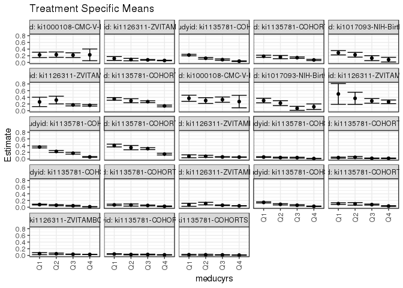

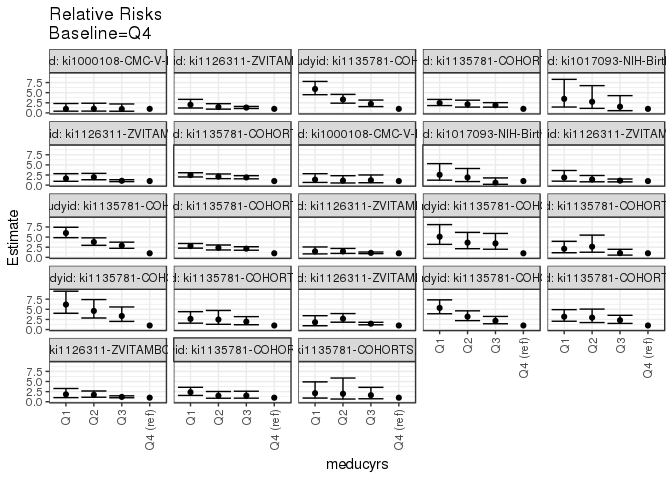

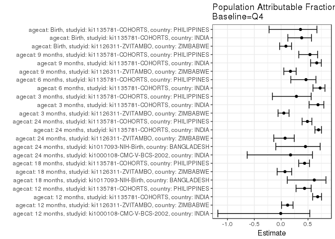

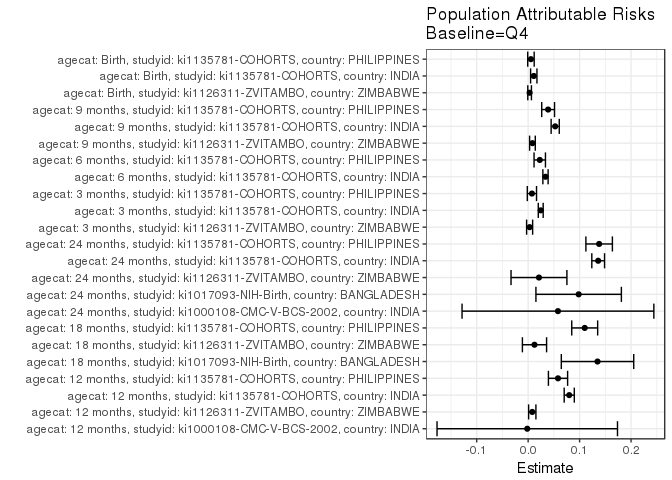

## Results Table

### Parameter: TSM

| agecat | studyid | country | intervention_level | baseline_level | estimate | ci_lower | ci_upper |
| --- | --- | --- | --- | --- | --- | --- | --- |
| Birth | ki1126311-ZVITAMBO | ZIMBABWE | Q4 | NA | 0.0290905 | 0.0255583 | 0.0326227 |
| Birth | ki1126311-ZVITAMBO | ZIMBABWE | Q1 | NA | 0.0528846 | 0.0224689 | 0.0833003 |
| Birth | ki1126311-ZVITAMBO | ZIMBABWE | Q2 | NA | 0.0500000 | 0.0291558 | 0.0708442 |
| Birth | ki1126311-ZVITAMBO | ZIMBABWE | Q3 | NA | 0.0347826 | 0.0294200 | 0.0401452 |
| Birth | ki1135781-COHORTS | INDIA | Q4 | NA | 0.0176337 | 0.0114807 | 0.0237867 |
| Birth | ki1135781-COHORTS | INDIA | Q1 | NA | 0.0415718 | 0.0322348 | 0.0509087 |
| Birth | ki1135781-COHORTS | INDIA | Q2 | NA | 0.0261661 | 0.0156123 | 0.0367199 |
| Birth | ki1135781-COHORTS | INDIA | Q3 | NA | 0.0267315 | 0.0157106 | 0.0377524 |
| Birth | ki1135781-COHORTS | PHILIPPINES | Q4 | NA | 0.0096463 | 0.0033736 | 0.0159190 |
| Birth | ki1135781-COHORTS | PHILIPPINES | Q1 | NA | 0.0203762 | 0.0094114 | 0.0313410 |
| Birth | ki1135781-COHORTS | PHILIPPINES | Q2 | NA | 0.0190840 | 0.0025141 | 0.0356538 |
| Birth | ki1135781-COHORTS | PHILIPPINES | Q3 | NA | 0.0156122 | 0.0086461 | 0.0225782 |
| 3 months | ki1126311-ZVITAMBO | ZIMBABWE | Q4 | NA | 0.0544537 | 0.0485874 | 0.0603201 |
| 3 months | ki1126311-ZVITAMBO | ZIMBABWE | Q1 | NA | 0.0800000 | 0.0365825 | 0.1234175 |
| 3 months | ki1126311-ZVITAMBO | ZIMBABWE | Q2 | NA | 0.0791367 | 0.0474019 | 0.1108715 |
| 3 months | ki1126311-ZVITAMBO | ZIMBABWE | Q3 | NA | 0.0596269 | 0.0511559 | 0.0680980 |
| 3 months | ki1135781-COHORTS | INDIA | Q4 | NA | 0.0111347 | 0.0063985 | 0.0158708 |
| 3 months | ki1135781-COHORTS | INDIA | Q1 | NA | 0.0566239 | 0.0461532 | 0.0670947 |
| 3 months | ki1135781-COHORTS | INDIA | Q2 | NA | 0.0403930 | 0.0276422 | 0.0531439 |
| 3 months | ki1135781-COHORTS | INDIA | Q3 | NA | 0.0382831 | 0.0254727 | 0.0510934 |
| 3 months | ki1135781-COHORTS | PHILIPPINES | Q4 | NA | 0.0184120 | 0.0094722 | 0.0273518 |
| 3 months | ki1135781-COHORTS | PHILIPPINES | Q1 | NA | 0.0389610 | 0.0236777 | 0.0542444 |
| 3 months | ki1135781-COHORTS | PHILIPPINES | Q2 | NA | 0.0483871 | 0.0216759 | 0.0750983 |
| 3 months | ki1135781-COHORTS | PHILIPPINES | Q3 | NA | 0.0192644 | 0.0112910 | 0.0272379 |
| 6 months | ki1135781-COHORTS | INDIA | Q4 | NA | 0.0126716 | 0.0076338 | 0.0177094 |
| 6 months | ki1135781-COHORTS | INDIA | Q1 | NA | 0.0782217 | 0.0657358 | 0.0907077 |
| 6 months | ki1135781-COHORTS | INDIA | Q2 | NA | 0.0582307 | 0.0428700 | 0.0735914 |
| 6 months | ki1135781-COHORTS | INDIA | Q3 | NA | 0.0424028 | 0.0288471 | 0.0559586 |
| 6 months | ki1135781-COHORTS | PHILIPPINES | Q4 | NA | 0.0261845 | 0.0151310 | 0.0372381 |
| 6 months | ki1135781-COHORTS | PHILIPPINES | Q1 | NA | 0.0690236 | 0.0486342 | 0.0894129 |

[output cut: 62 more lines]

### Parameter: E(Y)

| agecat | studyid | country | intervention_level | baseline_level | estimate | ci_lower | ci_upper |
| --- | --- | --- | --- | --- | --- | --- | --- |
| Birth | ki1126311-ZVITAMBO | ZIMBABWE | NA | NA | 0.0319334 | 0.0318512 | 0.0320155 |
| Birth | ki1135781-COHORTS | INDIA | NA | NA | 0.0285660 | 0.0282963 | 0.0288356 |
| Birth | ki1135781-COHORTS | PHILIPPINES | NA | NA | 0.0150820 | 0.0149383 | 0.0152257 |
| 3 months | ki1126311-ZVITAMBO | ZIMBABWE | NA | NA | 0.0573110 | 0.0571994 | 0.0574225 |
| 3 months | ki1135781-COHORTS | INDIA | NA | NA | 0.0355853 | 0.0350866 | 0.0360839 |
| 3 months | ki1135781-COHORTS | PHILIPPINES | NA | NA | 0.0257391 | 0.0253478 | 0.0261305 |
| 6 months | ki1135781-COHORTS | INDIA | NA | NA | 0.0463699 | 0.0456373 | 0.0471024 |
| 6 months | ki1135781-COHORTS | PHILIPPINES | NA | NA | 0.0487445 | 0.0481318 | 0.0493571 |
| 9 months | ki1126311-ZVITAMBO | ZIMBABWE | NA | NA | 0.0481535 | 0.0478455 | 0.0484615 |
| 9 months | ki1135781-COHORTS | INDIA | NA | NA | 0.0792580 | 0.0778757 | 0.0806403 |
| 9 months | ki1135781-COHORTS | PHILIPPINES | NA | NA | 0.0722714 | 0.0712273 | 0.0733154 |
| 12 months | ki1000108-CMC-V-BCS-2002 | INDIA | NA | NA | 0.2255435 | 0.2248980 | 0.2261889 |
| 12 months | ki1126311-ZVITAMBO | ZIMBABWE | NA | NA | 0.0663008 | 0.0660237 | 0.0665779 |
| 12 months | ki1135781-COHORTS | INDIA | NA | NA | 0.1173289 | 0.1150197 | 0.1196382 |
| 12 months | ki1135781-COHORTS | PHILIPPINES | NA | NA | 0.1330754 | 0.1314947 | 0.1346562 |
| 18 months | ki1017093-NIH-Birth | BANGLADESH | NA | NA | 0.2181426 | 0.2111716 | 0.2251135 |
| 18 months | ki1126311-ZVITAMBO | ZIMBABWE | NA | NA | 0.1738876 | 0.1723708 | 0.1754044 |
| 18 months | ki1135781-COHORTS | PHILIPPINES | NA | NA | 0.2516051 | 0.2485309 | 0.2546794 |
| 24 months | ki1000108-CMC-V-BCS-2002 | INDIA | NA | NA | 0.3306452 | 0.3275995 | 0.3336908 |
| 24 months | ki1017093-NIH-Birth | BANGLADESH | NA | NA | 0.2167832 | 0.2083544 | 0.2252121 |
| 24 months | ki1126311-ZVITAMBO | ZIMBABWE | NA | NA | 0.2866521 | 0.2829004 | 0.2904038 |
| 24 months | ki1135781-COHORTS | INDIA | NA | NA | 0.1954297 | 0.1917442 | 0.1991151 |
| 24 months | ki1135781-COHORTS | PHILIPPINES | NA | NA | 0.2817996 | 0.2779729 | 0.2856263 |

### Parameter: RR

| agecat | studyid | country | intervention_level | baseline_level | estimate | ci_lower | ci_upper |
| --- | --- | --- | --- | --- | --- | --- | --- |
| Birth | ki1126311-ZVITAMBO | ZIMBABWE | Q4 | Q4 | 1.0000000 | 1.0000000 | 1.000000 |
| Birth | ki1126311-ZVITAMBO | ZIMBABWE | Q1 | Q4 | 1.8179348 | 1.0099391 | 3.272363 |
| Birth | ki1126311-ZVITAMBO | ZIMBABWE | Q2 | Q4 | 1.7187747 | 1.1133845 | 2.653339 |
| Birth | ki1126311-ZVITAMBO | ZIMBABWE | Q3 | Q4 | 1.1956694 | 0.9826120 | 1.454924 |
| Birth | ki1135781-COHORTS | INDIA | Q4 | Q4 | 1.0000000 | 1.0000000 | 1.000000 |
| Birth | ki1135781-COHORTS | INDIA | Q1 | Q4 | 2.3575207 | 1.5568109 | 3.570057 |
| Birth | ki1135781-COHORTS | INDIA | Q2 | Q4 | 1.4838709 | 0.8705132 | 2.529396 |
| Birth | ki1135781-COHORTS | INDIA | Q3 | Q4 | 1.5159330 | 0.8832986 | 2.601672 |
| Birth | ki1135781-COHORTS | PHILIPPINES | Q4 | Q4 | 1.0000000 | 1.0000000 | 1.000000 |
| Birth | ki1135781-COHORTS | PHILIPPINES | Q1 | Q4 | 2.1123302 | 0.9082292 | 4.912789 |
| Birth | ki1135781-COHORTS | PHILIPPINES | Q2 | Q4 | 1.9783715 | 0.6686487 | 5.853528 |
| Birth | ki1135781-COHORTS | PHILIPPINES | Q3 | Q4 | 1.6184607 | 0.7355353 | 3.561237 |
| 3 months | ki1126311-ZVITAMBO | ZIMBABWE | Q4 | Q4 | 1.0000000 | 1.0000000 | 1.000000 |
| 3 months | ki1126311-ZVITAMBO | ZIMBABWE | Q1 | Q4 | 1.4691374 | 0.8448191 | 2.554825 |
| 3 months | ki1126311-ZVITAMBO | ZIMBABWE | Q2 | Q4 | 1.4532834 | 0.9594396 | 2.201319 |
| 3 months | ki1126311-ZVITAMBO | ZIMBABWE | Q3 | Q4 | 1.0950016 | 0.9161827 | 1.308722 |
| 3 months | ki1135781-COHORTS | INDIA | Q4 | Q4 | 1.0000000 | 1.0000000 | 1.000000 |
| 3 months | ki1135781-COHORTS | INDIA | Q1 | Q4 | 5.0853683 | 3.1981121 | 8.086324 |
| 3 months | ki1135781-COHORTS | INDIA | Q2 | Q4 | 3.6276773 | 2.1359340 | 6.161259 |
| 3 months | ki1135781-COHORTS | INDIA | Q3 | Q4 | 3.4381836 | 2.0011988 | 5.907013 |
| 3 months | ki1135781-COHORTS | PHILIPPINES | Q4 | Q4 | 1.0000000 | 1.0000000 | 1.000000 |
| 3 months | ki1135781-COHORTS | PHILIPPINES | Q1 | Q4 | 2.1160714 | 1.1335532 | 3.950197 |
| 3 months | ki1135781-COHORTS | PHILIPPINES | Q2 | Q4 | 2.6280241 | 1.2599244 | 5.481687 |
| 3 months | ki1135781-COHORTS | PHILIPPINES | Q3 | Q4 | 1.0463003 | 0.5528038 | 1.980349 |
| 6 months | ki1135781-COHORTS | INDIA | Q4 | Q4 | 1.0000000 | 1.0000000 | 1.000000 |
| 6 months | ki1135781-COHORTS | INDIA | Q1 | Q4 | 6.1729976 | 4.0219529 | 9.474477 |
| 6 months | ki1135781-COHORTS | INDIA | Q2 | Q4 | 4.5953714 | 2.8517300 | 7.405132 |
| 6 months | ki1135781-COHORTS | INDIA | Q3 | Q4 | 3.3462898 | 2.0091109 | 5.573438 |
| 6 months | ki1135781-COHORTS | PHILIPPINES | Q4 | Q4 | 1.0000000 | 1.0000000 | 1.000000 |
| 6 months | ki1135781-COHORTS | PHILIPPINES | Q1 | Q4 | 2.6360430 | 1.5746752 | 4.412797 |

[output cut: 62 more lines]

### Parameter: PAR

| agecat | studyid | country | intervention_level | baseline_level | estimate | ci_lower | ci_upper |
| --- | --- | --- | --- | --- | --- | --- | --- |
| Birth | ki1126311-ZVITAMBO | ZIMBABWE | Q4 | NA | 0.0028429 | -0.0006903 | 0.0063760 |
| Birth | ki1135781-COHORTS | INDIA | Q4 | NA | 0.0109323 | 0.0047733 | 0.0170912 |
| Birth | ki1135781-COHORTS | PHILIPPINES | Q4 | NA | 0.0054357 | -0.0008387 | 0.0117100 |
| 3 months | ki1126311-ZVITAMBO | ZIMBABWE | Q4 | NA | 0.0028572 | -0.0030102 | 0.0087247 |
| 3 months | ki1135781-COHORTS | INDIA | Q4 | NA | 0.0244506 | 0.0196883 | 0.0292129 |
| 3 months | ki1135781-COHORTS | PHILIPPINES | Q4 | NA | 0.0073272 | -0.0016212 | 0.0162755 |
| 6 months | ki1135781-COHORTS | INDIA | Q4 | NA | 0.0336983 | 0.0286074 | 0.0387891 |
| 6 months | ki1135781-COHORTS | PHILIPPINES | Q4 | NA | 0.0225599 | 0.0114894 | 0.0336304 |
| 9 months | ki1126311-ZVITAMBO | ZIMBABWE | Q4 | NA | 0.0083360 | 0.0028082 | 0.0138638 |
| 9 months | ki1135781-COHORTS | INDIA | Q4 | NA | 0.0525752 | 0.0446743 | 0.0604761 |
| 9 months | ki1135781-COHORTS | PHILIPPINES | Q4 | NA | 0.0388141 | 0.0263610 | 0.0512673 |
| 12 months | ki1000108-CMC-V-BCS-2002 | INDIA | Q4 | NA | -0.0017292 | -0.1770839 | 0.1736254 |
| 12 months | ki1126311-ZVITAMBO | ZIMBABWE | Q4 | NA | 0.0079952 | 0.0009044 | 0.0150860 |
| 12 months | ki1135781-COHORTS | INDIA | Q4 | NA | 0.0798536 | 0.0700324 | 0.0896748 |
| 12 months | ki1135781-COHORTS | PHILIPPINES | Q4 | NA | 0.0580431 | 0.0394009 | 0.0766853 |
| 18 months | ki1017093-NIH-Birth | BANGLADESH | Q4 | NA | 0.1348092 | 0.0644535 | 0.2051649 |
| 18 months | ki1126311-ZVITAMBO | ZIMBABWE | Q4 | NA | 0.0123248 | -0.0111723 | 0.0358218 |
| 18 months | ki1135781-COHORTS | PHILIPPINES | Q4 | NA | 0.1098939 | 0.0847077 | 0.1350801 |
| 24 months | ki1000108-CMC-V-BCS-2002 | INDIA | Q4 | NA | 0.0579179 | -0.1284591 | 0.2442948 |
| 24 months | ki1017093-NIH-Birth | BANGLADESH | Q4 | NA | 0.0981391 | 0.0151012 | 0.1811771 |
| 24 months | ki1126311-ZVITAMBO | ZIMBABWE | Q4 | NA | 0.0210271 | -0.0332650 | 0.0753192 |
| 24 months | ki1135781-COHORTS | INDIA | Q4 | NA | 0.1361076 | 0.1237238 | 0.1484914 |
| 24 months | ki1135781-COHORTS | PHILIPPINES | Q4 | NA | 0.1379640 | 0.1122163 | 0.1637116 |

### Parameter: PAF

| agecat | studyid | country | intervention_level | baseline_level | estimate | ci_lower | ci_upper |
| --- | --- | --- | --- | --- | --- | --- | --- |
| Birth | ki1126311-ZVITAMBO | ZIMBABWE | Q4 | NA | 0.0890257 | -0.0286090 | 0.1932073 |
| Birth | ki1135781-COHORTS | INDIA | Q4 | NA | 0.3827030 | 0.1248338 | 0.5645906 |
| Birth | ki1135781-COHORTS | PHILIPPINES | Q4 | NA | 0.3604082 | -0.2255796 | 0.6662170 |
| 3 months | ki1126311-ZVITAMBO | ZIMBABWE | Q4 | NA | 0.0498550 | -0.0582409 | 0.1469092 |
| 3 months | ki1135781-COHORTS | INDIA | Q4 | NA | 0.6870986 | 0.5211111 | 0.7955533 |
| 3 months | ki1135781-COHORTS | PHILIPPINES | Q4 | NA | 0.2846702 | -0.1627293 | 0.5599175 |
| 6 months | ki1135781-COHORTS | INDIA | Q4 | NA | 0.7267277 | 0.5931876 | 0.8164320 |
| 6 months | ki1135781-COHORTS | PHILIPPINES | Q4 | NA | 0.4628202 | 0.1805279 | 0.6478683 |
| 9 months | ki1126311-ZVITAMBO | ZIMBABWE | Q4 | NA | 0.1731124 | 0.0500315 | 0.2802466 |
| 9 months | ki1135781-COHORTS | INDIA | Q4 | NA | 0.6633421 | 0.5491538 | 0.7486093 |
| 9 months | ki1135781-COHORTS | PHILIPPINES | Q4 | NA | 0.5370609 | 0.3289949 | 0.6806096 |
| 12 months | ki1000108-CMC-V-BCS-2002 | INDIA | Q4 | NA | -0.0076670 | -1.1797244 | 0.5341646 |
| 12 months | ki1126311-ZVITAMBO | ZIMBABWE | Q4 | NA | 0.1205903 | 0.0068874 | 0.2212751 |
| 12 months | ki1135781-COHORTS | INDIA | Q4 | NA | 0.6805959 | 0.5876226 | 0.7526078 |
| 12 months | ki1135781-COHORTS | PHILIPPINES | Q4 | NA | 0.4361669 | 0.2775822 | 0.5599391 |
| 18 months | ki1017093-NIH-Birth | BANGLADESH | Q4 | NA | 0.6179867 | 0.1144783 | 0.8351998 |
| 18 months | ki1126311-ZVITAMBO | ZIMBABWE | Q4 | NA | 0.0708777 | -0.0745259 | 0.1966055 |
| 18 months | ki1135781-COHORTS | PHILIPPINES | Q4 | NA | 0.4367713 | 0.3278318 | 0.5280548 |
| 24 months | ki1000108-CMC-V-BCS-2002 | INDIA | Q4 | NA | 0.1751663 | -0.6335891 | 0.5835240 |
| 24 months | ki1017093-NIH-Birth | BANGLADESH | Q4 | NA | 0.4527064 | -0.0992092 | 0.7275038 |
| 24 months | ki1126311-ZVITAMBO | ZIMBABWE | Q4 | NA | 0.0733540 | -0.1367134 | 0.2446004 |
| 24 months | ki1135781-COHORTS | INDIA | Q4 | NA | 0.6964533 | 0.6291780 | 0.7515233 |
| 24 months | ki1135781-COHORTS | PHILIPPINES | Q4 | NA | 0.4895819 | 0.3904203 | 0.5726127 |